**Names:**

Sayantika Nag (snag007)

Joshua Pena (jpena079)

# Section 0: Video Link

Youtube link: https://youtu.be/ux6jaH9LsOQ

# Section 1 : Where CLIP fails: Few experiments

[Learning Transferable Visual Models From Natural Language Supervision](https://arxiv.org/abs/2103.00020)

```python
import torch
from PIL import Image
import matplotlib.pyplot as plt
from transformers import CLIPProcessor, CLIPModel
import os

device = "cuda" if torch.cuda.is_available() else "cpu"

model_id = "openai/clip-vit-base-patch32"
model = CLIPModel.from_pretrained(model_id).to(device)
processor = CLIPProcessor.from_pretrained(model_id)
```

```python
from google.colab import drive
drive.mount('/content/drive')
```

## Experiment 1: Object relationship failure

```python
# Define the folder containing images:
image_folder = "/content/drive/MyDrive/Colab Notebooks/homework_243/project on CLIP/dogcatimages"
print(f"Looking for images in: {image_folder}")

# List all files in the directory and filter for common image extensions:
image_files = [f for f in os.listdir(image_folder) if f.lower().endswith(('.png', '.jpg', '.jpeg', '.gif', '.bmp'))]


# Text Prompts:
texts = [
    "a dog chasing a cat",
    "a cat chasing a dog",
    "a dog next to a cat",
    "a cat next to a dog",
    " a dog in the grass",
    "a cat in the grass",
    "a dog and a cat in the grass"
]
```

```
Looking for images in: /content/drive/MyDrive/Colab Notebooks/homework_243/project on CLIP/dogcatimages
```

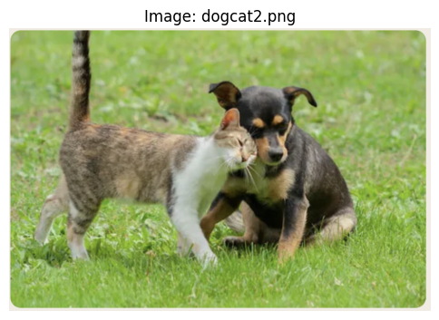

```
CLIP analysis results:
  a dog chasing a cat: 0.5540
  a cat chasing a dog: 0.3224
  a dog next to a cat: 0.0692
  a cat next to a dog: 0.0373
   a dog in the grass: 0.0001
  a cat in the grass: 0.0001
  a dog and a cat in the grass: 0.0169
--------------------------------------------------
```

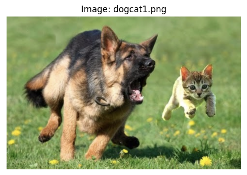

```
CLIP analysis results:
  a dog chasing a cat: 0.5878
  a cat chasing a dog: 0.4089
  a dog next to a cat: 0.0015
  a cat next to a dog: 0.0009
   a dog in the grass: 0.0000
  a cat in the grass: 0.0000
  a dog and a cat in the grass: 0.0009
--------------------------------------------------
```

```python
# Zero-shot prediction:

for image_name in image_files:

        image_path = os.path.join(image_folder, image_name)
        image = Image.open(image_path).convert("RGB")

        # plot the image:
        plt.figure(figsize=(6, 6))
        plt.imshow(image)
        plt.title(f"Image: {image_name}")
        plt.axis("off")
        plt.show()


        # prediction:
        inputs = processor(
            text=texts,
            images=image,
            return_tensors="pt",
            padding=True
        ).to(device)

        with torch.no_grad():
            outputs = model(**inputs)
            probs = outputs.logits_per_image.softmax(dim=1)[0]

        print("CLIP analysis results:")
        for text, p in zip(texts, probs):
            print(f"  {text}: {p.item():.4f}")
        print("-" * 50)
```

## Experiment 2: Prompt sensitivity experiment

Check whether changing the prompt changes CLIP's answer.

```python
import numpy as np
import pandas as pd

def prompt_sensitivity_clip(image_path, question, candidate_answers):
    templates = [
        "Question: {} Answer: {}",
        "Q: {} A: {}",
        "The answer to '{}' is '{}'",
        "A photo where the answer to the question '{}' is '{}'",
        "{} {}",
        "Based on the image, the answer to '{}' is '{}'",
        "In this image, '{}'",
        "This image shows '{}'",
    ]

    raw_image = Image.open(image_path).convert("RGB")
    all_results = []

    for template in templates:
        prompts = [template.format(question, ans) for ans in candidate_answers]

        inputs = processor(
            text=prompts,
            images=raw_image,
            return_tensors="pt",
            padding=True
        ).to(device)

        with torch.no_grad():
            outputs = model(**inputs)
            probs = outputs.logits_per_image.softmax(dim=1).squeeze()

        probs = probs.reshape(-1)

        pred_idx = probs.argmax().item()
        pred_answer = candidate_answers[pred_idx]
        pred_prob = probs[pred_idx].item()

        row = {
            "Template": template,
            "Predicted Answer": pred_answer,
            "Confidence": pred_prob
        }

        for ans, p in zip(candidate_answers, probs):
            row[ans] = p.item()

        all_results.append(row)

    return pd.DataFrame(all_results)


def compute_entropy(row):

    probs = row.values.astype(float)

    return -np.sum(probs * np.log(probs + 1e-12))
```

```
Starting Prompt Sensitivity Experiment...

--- Running prompt sensitivity for image: dogcat2.png ---
```

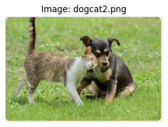

|  | Template | Predicted Answer | Confidence | a dog chasing a cat | a cat chasing a dog | a dog next to a cat | a cat next to a dog | a dog and cat on grass | Entropy |
| --- | --- | --- | --- | --- | --- | --- | --- | --- | --- |
| 0 | Question: {} Answer: {} | a dog chasing a cat | 0.396027 | 0.396027 | 0.209123 | 0.226715 | 0.140198 | 0.027937 | 1.405931 |
| 1 | Q: {} A: {} | a dog chasing a cat | 0.530417 | 0.530417 | 0.293395 | 0.092001 | 0.063851 | 0.020337 | 1.170500 |
| 2 | The answer to '{}' is '{}' | a dog chasing a cat | 0.334941 | 0.334941 | 0.290472 | 0.168037 | 0.162157 | 0.044393 | 1.458423 |
| 3 | A photo where the answer to the question '{}' ... | a dog chasing a cat | 0.375801 | 0.375801 | 0.298105 | 0.137487 | 0.120815 | 0.067792 | 1.439191 |
| 4 | {} {} | a dog chasing a cat | 0.586864 | 0.586864 | 0.237848 | 0.108030 | 0.058403 | 0.008855 | 1.102503 |
| 5 | Based on the image, the answer to '{}' is '{}' | a dog chasing a cat | 0.249994 | 0.249994 | 0.241827 | 0.230546 | 0.217880 | 0.059754 | 1.528499 |
| 6 | In this image, '{}' | a dog chasing a cat | 0.200000 | 0.200000 | 0.200000 | 0.200000 | 0.200000 | 0.200000 | 1.609438 |
| 7 | This image shows '{}' | a dog chasing a cat | 0.200000 | 0.200000 | 0.200000 | 0.200000 | 0.200000 | 0.200000 | 1.609438 |

```
Prompt Consistency Score: 1.0
Interpretation: CLIP prediction is stable across prompt templates.

--- Running prompt sensitivity for image: dogcat1.png ---
```

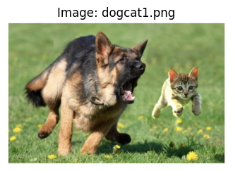

|  | Template | Predicted Answer | Confidence | a dog chasing a cat | a cat chasing a dog | a dog next to a cat | a cat next to a dog | a dog and cat on grass | Entropy |
| --- | --- | --- | --- | --- | --- | --- | --- | --- | --- |
| 0 | Question: {} Answer: {} | a dog chasing a cat | 0.573399 | 0.573399 | 0.406253 | 0.008816 | 0.007197 | 0.004335 | 0.785659 |
| 1 | Q: {} A: {} | a dog chasing a cat | 0.570250 | 0.570250 | 0.412654 | 0.005463 | 0.005618 | 0.006016 | 0.773887 |
| 2 | The answer to '{}' is '{}' | a cat chasing a dog | 0.486591 | 0.478266 | 0.486591 | 0.011632 | 0.010997 | 0.012514 | 0.859499 |
| 3 | A photo where the answer to the question '{}' ... | a dog chasing a cat | 0.501717 | 0.501717 | 0.478643 | 0.005590 | 0.005395 | 0.008656 | 0.796986 |
| 4 | {} {} | a dog chasing a cat | 0.630083 | 0.630083 | 0.358988 | 0.005657 | 0.003704 | 0.001567 | 0.718944 |
| 5 | Based on the image, the answer to '{}' is '{}' | a cat chasing a dog | 0.491725 | 0.457151 | 0.491725 | 0.015920 | 0.014710 | 0.020493 | 0.914523 |
| 6 | In this image, '{}' | a dog chasing a cat | 0.200000 | 0.200000 | 0.200000 | 0.200000 | 0.200000 | 0.200000 | 1.609438 |
| 7 | This image shows '{}' | a dog chasing a cat | 0.200000 | 0.200000 | 0.200000 | 0.200000 | 0.200000 | 0.200000 | 1.609438 |

```
Prompt Consistency Score: 0.75
Interpretation: CLIP is sensitive to prompt wording.
```

```python
print("Starting Prompt Sensitivity Experiment...")

# Define a generic question for the experiment:
question_for_sensitivity = "What is in the image?"

# Define candidate answers:
candidate_answers_for_sensitivity = [
    "a dog chasing a cat",
    "a cat chasing a dog",
    "a dog next to a cat",
    "a cat next to a dog",
    "a dog and cat on grass"
]


for image_name in image_files:
        image_path = os.path.join(image_folder, image_name)

        print(f"\n--- Running prompt sensitivity for image: {image_name} ---")

        image = Image.open(image_path).convert("RGB")
        plt.figure(figsize=(4, 4))
        plt.imshow(image)
        plt.title(f"Image: {image_name}")
        plt.axis("off")
        plt.show()

        df_results = prompt_sensitivity_clip(
                image_path=image_path,
                question=question_for_sensitivity,
                candidate_answers=candidate_answers_for_sensitivity
            )

        df_results["Entropy"] = df_results[
                candidate_answers_for_sensitivity
            ].apply(compute_entropy, axis=1)

        consistency_score = (
                df_results["Predicted Answer"].value_counts().max()
                / len(df_results)
            )

        display(df_results)

        print("Prompt Consistency Score:", consistency_score)

        if consistency_score == 1.0:
                print("Interpretation: CLIP prediction is stable across prompt templates.")
        else:
                print("Interpretation: CLIP is sensitive to prompt wording.")
```

## Experiment 3: Localization Limitation using GradCAM

```python
from transformers import CLIPProcessor, CLIPModel
import torch
import cv2
import numpy as np
from PIL import Image
import matplotlib.pyplot as plt

device = "cuda" if torch.cuda.is_available() else "cpu"

model_id = "openai/clip-vit-base-patch32"
model = CLIPModel.from_pretrained(model_id).to(device)
processor = CLIPProcessor.from_pretrained(model_id)
model.eval()
```

[output not shown]

[output not shown]

```python
class CLIPGradCAM:
    def __init__(self, model):
        self.model = model
        self.gradients = None
        self.activations = None

        # For ViT-B/32 CLIP vision encoder
        target_layer = self.model.vision_model.encoder.layers[-1].layer_norm1

        target_layer.register_forward_hook(self.save_activation)
        target_layer.register_full_backward_hook(self.save_gradient)

    def save_activation(self, module, input, output):
        self.activations = output

    def save_gradient(self, module, grad_input, grad_output):
        self.gradients = grad_output[0]

    def generate_cam(self, image, text_prompt):
        inputs = processor(
            text=[text_prompt],
            images=image,
            return_tensors="pt",
            padding=True
        ).to(device)

        self.model.zero_grad()

        outputs = self.model(**inputs)
        score = outputs.logits_per_image[0, 0]

        score.backward()

        gradients = self.gradients[:, 1:, :]
        activations = self.activations[:, 1:, :]

        weights = gradients.mean(dim=1, keepdim=True)
        cam = (weights * activations).sum(dim=-1)

        cam = torch.relu(cam)
        cam = cam.reshape(7, 7)

        cam = cam.detach().cpu().numpy()
        cam = cv2.resize(cam, image.size)

        cam = cam - cam.min()
        cam = cam / (cam.max() + 1e-8)

        return cam
```

```python
# overlay of grad-cam on image:
def show_gradcam(image_path, text_prompt):
    image = Image.open(image_path).convert("RGB")

    gradcam = CLIPGradCAM(model)
    cam = gradcam.generate_cam(image, text_prompt)

    img_np = np.array(image)

    heatmap = cv2.applyColorMap(
        np.uint8(255 * cam),
        cv2.COLORMAP_JET
    )

    heatmap = cv2.cvtColor(heatmap, cv2.COLOR_BGR2RGB)

    overlay = 0.6 * img_np + 0.4 * heatmap
    overlay = np.uint8(overlay)

    plt.figure(figsize=(12, 5))

    plt.subplot(1, 3, 1)
    plt.imshow(image)
    plt.title("Original Image")
    plt.axis("off")

    plt.subplot(1, 3, 2)
    plt.imshow(cam, cmap="jet")
    plt.title("Grad-CAM Heatmap")
    plt.axis("off")

    plt.subplot(1, 3, 3)
    plt.imshow(overlay)
    plt.title(f"Overlay: {text_prompt}")
    plt.axis("off")

    plt.show()
```

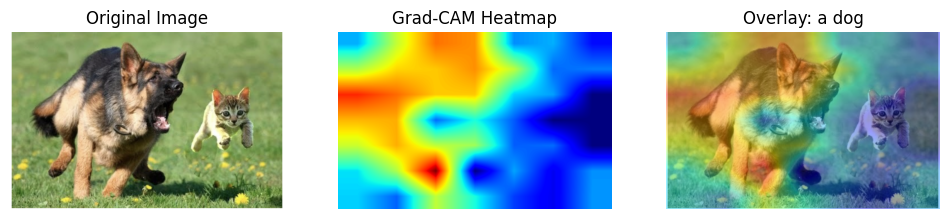

```python
# run localization experiments:
show_gradcam(
    image_path="/content/drive/MyDrive/Colab Notebooks/homework_243/project on CLIP/dogcatimages/dogcat1.png",
    text_prompt="a dog"
)
```

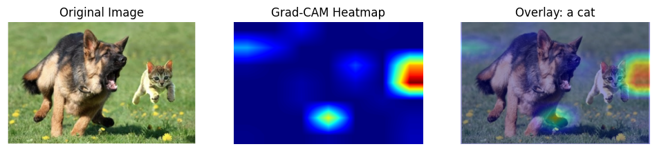

```python
show_gradcam(
    image_path="/content/drive/MyDrive/Colab Notebooks/homework_243/project on CLIP/dogcatimages/dogcat1.png",
    text_prompt="a cat"
)
```

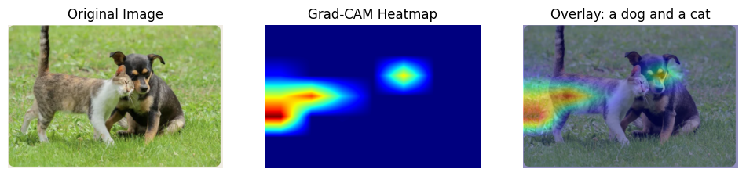

```python
show_gradcam(
    image_path="/content/drive/MyDrive/Colab Notebooks/homework_243/project on CLIP/dogcatimages/dogcat2.png",
    text_prompt="a dog and a cat"

)
```

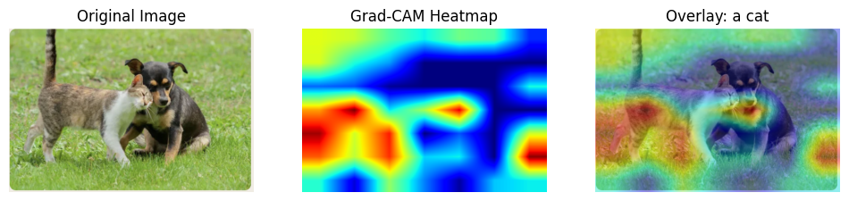

```python
show_gradcam(
    image_path="/content/drive/MyDrive/Colab Notebooks/homework_243/project on CLIP/dogcatimages/dogcat2.png",
    text_prompt="a cat"

)
```

## Experiment 4: CLIP weakness on out of the distribution data- MNIST

```python
from tqdm import tqdm
from torchvision.datasets import MNIST
import pandas as pd
# Load the Mnist data set:
mnist_test = MNIST(
    root="./data",
    train=False,
    download=True
)
```

```python
digit_prompts = [
    "a handwritten digit zero",
    "a handwritten digit one",
    "a handwritten digit two",
    "a handwritten digit three",
    "a handwritten digit four",
    "a handwritten digit five",
    "a handwritten digit six",
    "a handwritten digit seven",
    "a handwritten digit eight",
    "a handwritten digit nine"
]

digit_labels = list(range(10))
```

```python
# zero-shot prediction function:
def predict_digit_clip(image):
    image = image.convert("RGB")

    inputs = processor(
        text=digit_prompts,
        images=image,
        return_tensors="pt",
        padding=True
    ).to(device)

    with torch.no_grad():
        outputs = model(**inputs)
        probs = outputs.logits_per_image.softmax(dim=1).squeeze()

    pred_idx = probs.argmax().item()
    confidence = probs[pred_idx].item()

    return pred_idx, confidence, probs.cpu()
```

```python
results = []

for idx in tqdm(range(len(mnist_test))):
    image, true_label = mnist_test[idx]

    pred_label, confidence, probs = predict_digit_clip(image)

    results.append({
        "index": idx,
        "true_label": true_label,
        "pred_label": pred_label,
        "confidence": confidence,
        "correct": true_label == pred_label
    })
```

```python
import pandas as pd

df = pd.DataFrame(results)
df.head()
```

|  | index | true_label | pred_label | confidence | correct |
| --- | --- | --- | --- | --- | --- |
| 0 | 0 | 7 | 2 | 0.318351 | False |
| 1 | 1 | 2 | 2 | 0.261386 | True |
| 2 | 2 | 1 | 2 | 0.157818 | False |
| 3 | 3 | 0 | 0 | 0.153450 | True |
| 4 | 4 | 4 | 3 | 0.145997 | False |

```python
display(df)
```

|  | index | true_label | pred_label | confidence | correct |
| --- | --- | --- | --- | --- | --- |
| 0 | 0 | 7 | 2 | 0.318351 | False |
| 1 | 1 | 2 | 2 | 0.261386 | True |
| 2 | 2 | 1 | 2 | 0.157818 | False |
| 3 | 3 | 0 | 0 | 0.153450 | True |
| 4 | 4 | 4 | 3 | 0.145997 | False |
| ... | ... | ... | ... | ... | ... |
| 9995 | 9995 | 2 | 2 | 0.302231 | True |
| 9996 | 9996 | 3 | 3 | 0.220006 | True |
| 9997 | 9997 | 4 | 2 | 0.164589 | False |
| 9998 | 9998 | 5 | 7 | 0.162174 | False |
| 9999 | 9999 | 6 | 0 | 0.200930 | False |

10000 rows × 5 columns

```python
accuracy = df["correct"].mean()
print("CLIP zero-shot MNIST accuracy:", accuracy)
```

```
CLIP zero-shot MNIST accuracy: 0.227
```

```python
# confusion matrix:
pd.crosstab(
    df["true_label"],
    df["pred_label"],
    rownames=["True"],
    colnames=["Predicted"]
)
```

| Predicted True | 0 | 1 | 2 | 3 | 4 | 5 | 6 | 7 | 8 | 9 |
| --- | --- | --- | --- | --- | --- | --- | --- | --- | --- | --- |
| 0 | 465 | 0 | 416 | 0 | 0 | 0 | 0 | 0 | 99 | 0 |
| 1 | 35 | 1 | 1051 | 5 | 1 | 1 | 0 | 0 | 41 | 0 |
| 2 | 47 | 0 | 967 | 7 | 0 | 0 | 1 | 0 | 10 | 0 |
| 3 | 8 | 0 | 222 | 728 | 0 | 0 | 12 | 35 | 5 | 0 |
| 4 | 90 | 0 | 423 | 380 | 3 | 0 | 23 | 38 | 25 | 0 |
| 5 | 52 | 0 | 46 | 89 | 1 | 0 | 502 | 197 | 5 | 0 |
| 6 | 89 | 0 | 576 | 113 | 0 | 0 | 31 | 1 | 148 | 0 |
| 7 | 21 | 0 | 992 | 7 | 2 | 0 | 0 | 3 | 3 | 0 |
| 8 | 15 | 0 | 520 | 143 | 5 | 0 | 199 | 26 | 66 | 0 |
| 9 | 5 | 0 | 711 | 165 | 2 | 0 | 35 | 5 | 80 | 6 |

```python
# Find High Confidence Failures:
failures = df[df["correct"] == False].sort_values(
    "confidence",
    ascending=False
)

failures.head(20)
```

|  | index | true_label | pred_label | confidence | correct |
| --- | --- | --- | --- | --- | --- |
| 3705 | 3705 | 8 | 6 | 0.445529 | False |
| 3600 | 3600 | 2 | 0 | 0.432883 | False |
| 9595 | 9595 | 2 | 0 | 0.422558 | False |
| 2977 | 2977 | 2 | 0 | 0.418451 | False |
| 3106 | 3106 | 2 | 0 | 0.404272 | False |
| 9015 | 9015 | 7 | 0 | 0.402470 | False |
| 1499 | 1499 | 8 | 6 | 0.401931 | False |
| 2774 | 2774 | 8 | 6 | 0.401123 | False |
| 4666 | 4666 | 2 | 0 | 0.400131 | False |
| 3164 | 3164 | 6 | 0 | 0.397500 | False |
| 996 | 996 | 2 | 0 | 0.386181 | False |
| 3808 | 3808 | 7 | 0 | 0.383095 | False |
| 1498 | 1498 | 7 | 2 | 0.382116 | False |
| 9046 | 9046 | 2 | 0 | 0.380069 | False |
| 9893 | 9893 | 2 | 0 | 0.378513 | False |
| 3772 | 3772 | 2 | 0 | 0.377080 | False |
| 9515 | 9515 | 7 | 2 | 0.376897 | False |
| 2517 | 2517 | 2 | 0 | 0.373008 | False |
| 8398 | 8398 | 7 | 2 | 0.369696 | False |
| 2505 | 2505 | 7 | 2 | 0.369473 | False |

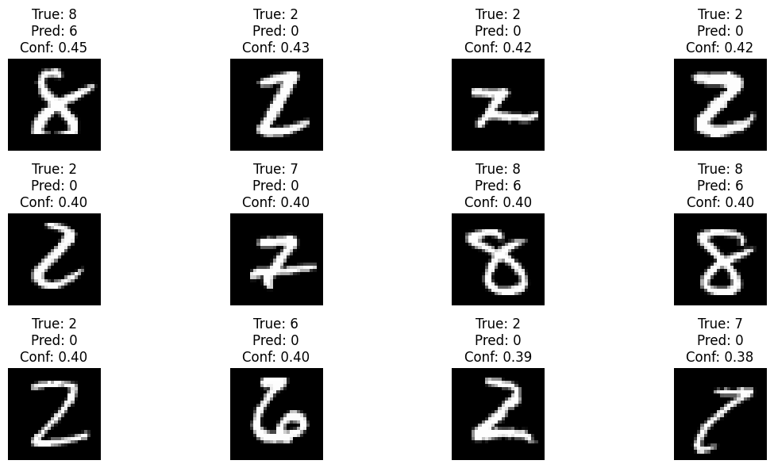

```python
# visualize CLIP failures:
def show_failures(failures_df, n=12):
    sample = failures_df.head(n)

    plt.figure(figsize=(12, 6))

    for i, (_, row) in enumerate(sample.iterrows()):
        image, true_label = mnist_test[int(row["index"])]

        plt.subplot(3, 4, i + 1)
        plt.imshow(image, cmap="gray")
        plt.axis("off")
        plt.title(
            f"True: {true_label}\nPred: {row['pred_label']}\nConf: {row['confidence']:.2f}"
        )

    plt.tight_layout()
    plt.show()

show_failures(failures, n=12)
```

```python
# Compare different prompt
prompt_sets = {
    "handwritten digit": [
        f"a handwritten digit {word}" for word in
        ["zero","one","two","three","four","five","six","seven","eight","nine"]
    ],
    "number only": [
        f"the number {i}" for i in range(10)
    ],
    "image of digit": [
        f"an image of the digit {i}" for i in range(10)
    ],
    "mnist style": [
        f"a black and white handwritten number {i}" for i in range(10)
    ]
}
```

```python
def predict_with_prompts(image, prompts):
    image = image.convert("RGB")

    inputs = processor(
        text=prompts,
        images=image,
        return_tensors="pt",
        padding=True
    ).to(device)

    with torch.no_grad():
        outputs = model(**inputs)
        probs = outputs.logits_per_image.softmax(dim=1).squeeze()

    pred = probs.argmax().item()
    conf = probs[pred].item()

    return pred, conf
```

```python
prompt_results = []

for prompt_name, prompts in prompt_sets.items():
    correct = 0

    for idx in tqdm(range(len(mnist_test)), desc=prompt_name):
        image, true_label = mnist_test[idx]
        pred, conf = predict_with_prompts(image, prompts)

        correct += int(pred == true_label)

    acc = correct / len(mnist_test)

    prompt_results.append({
        "Prompt Style": prompt_name,
        "Accuracy": acc
    })

prompt_df = pd.DataFrame(prompt_results)
prompt_df
```

|  | Prompt Style | Accuracy |
| --- | --- | --- |
| 0 | handwritten digit | 0.2270 |
| 1 | number only | 0.3068 |
| 2 | image of digit | 0.2814 |
| 3 | mnist style | 0.1393 |

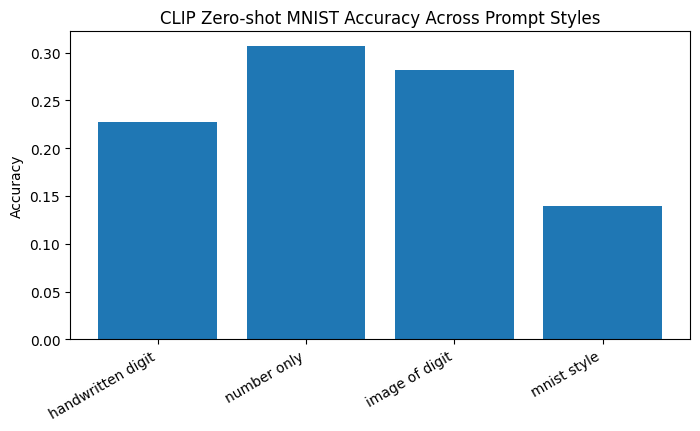

```python
plt.figure(figsize=(8, 4))
plt.bar(prompt_df["Prompt Style"], prompt_df["Accuracy"])
plt.ylabel("Accuracy")
plt.title("CLIP Zero-shot MNIST Accuracy Across Prompt Styles")
plt.xticks(rotation=30, ha="right")
plt.show()
```

# Section 2: Frontier Paper 1:

[VideoChat: chat-centric video understanding](https://link.springer.com/article/10.1007/s11432-024-4321-9#Abs1)

VideoChat is an end-to-end chat-centric video understanding system that integrates video foundation models with large language models (LLMs). Instead of treating video analysis as a set of isolated vision tasks, it bridges the gap between raw visual perception and complex semantic reasoning. By learning from both video-text pairs and instruction-tuning datasets, the authors created a system capable of spatiotemporal reasoning, event localization, and causal inference, allowing users to converse naturally about the contents of a video.

## **How VideoChat improves on CLIP?**

Unlike standard vision-language models like CLIP, which process images globally and act like a "bag of words" without an inherent understanding of time or sequence, VideoChat is built for spatiotemporal context. By integrating visual encoders with a generative language decoder, it gains precise spatial perception, state-awareness, and the ability to track causal relationships (e.g., directionality and intermediate event states). However, as highlighted in the paper and the experiments, scaling this architecture to handle extremely long-term contexts in sequential video processing remains a challenge, as the LLM's attention can become overwhelmed by the sheer number of temporal tokens.

## Experiment 5: CLIP weakness compared to VideoChat - Spatiotemporal Reasoning and Causal Inference

As highlighted in the VideoChat paper, vision models often struggle with event localization and causal relationships. Since CLIP processes images as a whole without an inherent understanding of time or sequence, let's test if it can distinguish the direction of a simple event using a synthetic 'Before and After' panel.

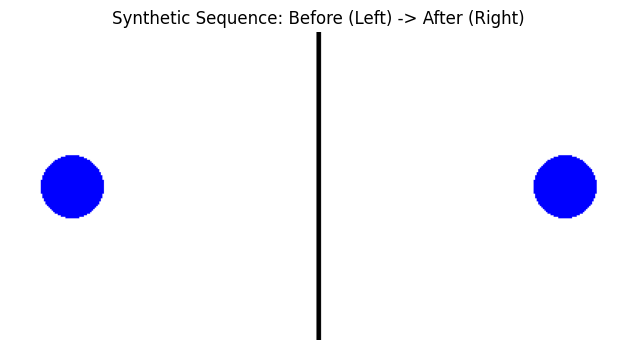

```python
from PIL import Image, ImageDraw
import matplotlib.pyplot as plt

# 1. Create a synthetic "sequence" image (Left Panel -> Right Panel)
img_size = (200, 200)

# Frame 1: Blue circle on the left
frame1 = Image.new('RGB', img_size, color='white')
draw1 = ImageDraw.Draw(frame1)
draw1.ellipse([20, 80, 60, 120], fill='blue')

# Frame 2: Blue circle on the right
frame2 = Image.new('RGB', img_size, color='white')
draw2 = ImageDraw.Draw(frame2)
draw2.ellipse([140, 80, 180, 120], fill='blue')

# Combine side-by-side to represent a timeline (Left = Before, Right = After)
combined_img = Image.new('RGB', (400, 200), color='white')
combined_img.paste(frame1, (0, 0))
combined_img.paste(frame2, (200, 0))

# Draw a dividing line
draw_comb = ImageDraw.Draw(combined_img)
draw_comb.line([200, 0, 200, 200], fill='black', width=3)

plt.figure(figsize=(8, 4))
plt.imshow(combined_img)
plt.title("Synthetic Sequence: Before (Left) -> After (Right)")
plt.axis('off')
plt.show()
```

```python
import torch
from transformers import CLIPProcessor, CLIPModel

# 1.5 Initialize model and processor if not already in session
device = "cuda" if torch.cuda.is_available() else "cpu"
model_id = "openai/clip-vit-base-patch32"
model = CLIPModel.from_pretrained(model_id).to(device)
processor = CLIPProcessor.from_pretrained(model_id)

# 2. Define prompts testing temporal/causal reasoning
sequence_prompts = [
    "A blue circle moves from left to right.",  # Correct temporal order
    "A blue circle moves from right to left.",  # Reversed temporal order
    "Two blue circles are sitting still."
]

print("Testing CLIP's spatiotemporal reasoning...")

# 3. Run CLIP inference
inputs = processor(
    text=sequence_prompts,
    images=combined_img,
    return_tensors="pt",
    padding=True
).to(device)

with torch.no_grad():
    outputs = model(**inputs)
    probs = outputs.logits_per_image.softmax(dim=1)[0]

print("\n--- CLIP Predictions ---")
for prompt, p in zip(sequence_prompts, probs):
    print(f"Confidence for '{prompt}': {p.item():.4f}")

print("\n--- Interpretation ---")
print("If CLIP assigns similar probabilities to 'left to right' and 'right to left', it confirms the limitation identified in the paper: standard vision-language models struggle with causal relationships and event directionality.")
```

[output not shown]

```
Testing CLIP's spatiotemporal reasoning...

--- CLIP Predictions ---
Confidence for 'A blue circle moves from left to right.': 0.3579
Confidence for 'A blue circle moves from right to left.': 0.5988
Confidence for 'Two blue circles are sitting still.': 0.0432

--- Interpretation ---
If CLIP assigns similar probabilities to 'left to right' and 'right to left', it confirms the limitation identified in the paper: standard vision-language models struggle with causal relationships and event directionality.
```

This perfectly demonstrates the limitation highlighted in the VideoChat paper: standard vision-language models struggle with spatiotemporal reasoning and causal relationships. Because CLIP processes the image globally and acts somewhat like a "bag of words" for text, it recognizes the concepts (blue circle, left, right) but completely lacks the ability to understand the sequence, time, or direction of the event.

## Experiment 6: CLIP weakness compared to VideoChat - Event Localization in a Sequence

The paper points out that vision models struggle with **event localization**. This means identifying the exact moment or state of an ongoing action in a video. Let's simulate a 3-frame sequence of a ball falling and see if CLIP can precisely match the correct frame to the description of the event's stage.

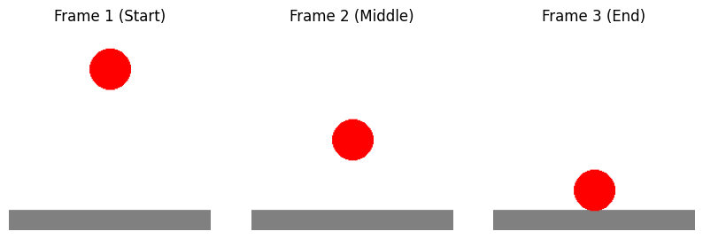

```python
import seaborn as sns
from PIL import Image, ImageDraw
import matplotlib.pyplot as plt

# 1. Create frames simulating a video of an object falling
img_size = (200, 200)

def create_falling_frame(y_pos):
    img = Image.new('RGB', img_size, color='white')
    draw = ImageDraw.Draw(img)
    # Draw the ground
    draw.rectangle([0, 180, 200, 200], fill='gray')
    # Draw the falling object
    draw.ellipse([80, y_pos, 120, y_pos + 40], fill='red')
    return img

# Create 3 distinct states
frames = [
    create_falling_frame(20),   # Start: High up
    create_falling_frame(90),   # Middle: Falling
    create_falling_frame(140)   # End: Hit the ground (140+40=180)
]
frame_names = ["Frame 1 (Start)", "Frame 2 (Middle)", "Frame 3 (End)"]

# Visualize the simulated video frames
fig, axes = plt.subplots(1, 3, figsize=(10, 3))
for ax, frame, name in zip(axes, frames, frame_names):
    ax.imshow(frame)
    ax.set_title(name)
    ax.axis('off')
plt.show()
```

```
Running CLIP inference to localize the event stages...
```

[figure not shown]

```
--- Interpretation ---
In a model with perfect event localization, this heatmap would be a clean diagonal matrix (1.0 across the diagonal).
If CLIP heavily mixes up the states (e.g., confidently predicting the 'End' prompt for the 'Start' frame just because it sees a red ball and gray ground), it proves the paper's point that it struggles to track intermediate states and localize events accurately.
```

```python
# 2. Define prompts representing temporal event stages
prompts_localization = [
    "A red ball is at the top, just about to fall.",
    "A red ball is falling through the air in the middle.",
    "A red ball has hit the gray ground."
]

print("Running CLIP inference to localize the event stages...")

# 3. Run zero-shot classification on all frames simultaneously
inputs_loc = processor(
    text=prompts_localization,
    images=frames,
    return_tensors="pt",
    padding=True
).to(device)

with torch.no_grad():
    outputs_loc = model(**inputs_loc)
    # We want the probability of each text for each image
    probs_loc = outputs_loc.logits_per_image.softmax(dim=1)

# 4. Plot the results as a heatmap
plt.figure(figsize=(9, 6))
sns.heatmap(probs_loc.cpu().numpy(), annot=True, cmap="Blues", fmt=".3f",
            xticklabels=["Start Prompt", "Middle Prompt", "End Prompt"],
            yticklabels=frame_names)
plt.title("CLIP Event Localization (Image-Text Probabilities)")
plt.xlabel("Text Prompts (Event Stage)")
plt.ylabel("Video Frames")
plt.show()

print("\n--- Interpretation ---")
print("In a model with perfect event localization, this heatmap would be a clean diagonal matrix (1.0 across the diagonal). ")
print("If CLIP heavily mixes up the states (e.g., confidently predicting the 'End' prompt for the 'Start' frame just because it sees a red ball and gray ground), it proves the paper's point that it struggles to track intermediate states and localize events accurately.")
```

CLIP fails to produce a perfect diagonal, meaning it confuses the states. Instead, it assigns high probabilities across multiple frames for the same prompt, or gets confused between the 'Start', 'Middle', and 'End' stages.

This perfectly illustrates the second weakness mentioned in the VideoChat paper: struggling with event localization. Because CLIP doesn't understand the process of falling or the specific physical state of the action, it simply sees a 'red ball' and 'gray ground' in all frames and struggles to isolate the exact temporal stage.

## Experiment 7: VideoChat weaknesses - Sequential Video Processing

To properly test the long-term context limits of Video-LLMs, we must use an actual `.mp4` file. We will create a 20-second video (600 frames). A blue square will appear only in the first 5 frames, followed by 595 frames of a red square.

We will then challenge a Video-LLM to recall the blue square, simulating a long-term context overload.

```python
import cv2
import numpy as np

# Parameters for a long video
width, height = 224, 224
fps = 30
seconds = 20 # 600 frames
video_path = "long_context_test.mp4"

# Initialize OpenCV Video Writer
fourcc = cv2.VideoWriter_fourcc(*'mp4v')
video = cv2.VideoWriter(video_path, fourcc, fps, (width, height))

print(f"Generating {fps * seconds} frames...")
for i in range(fps * seconds):
    frame = np.ones((height, width, 3), dtype=np.uint8) * 255
    if i < 5:
        # Only the first 5 frames (1/6th of a second) have the blue square
        cv2.rectangle(frame, (50, 50), (174, 174), (255, 0, 0), -1) # Blue in BGR
    else:
        # The rest of the video is red
        cv2.rectangle(frame, (50, 50), (174, 174), (0, 0, 255), -1) # Red in BGR
    video.write(frame)

video.release()
print(f"Saved synthetic video to {video_path}")
```

```
Generating 600 frames...
Saved synthetic video to long_context_test.mp4
```

```python
# Install necessary libraries for Video-LLM processing
!pip install -q qwen-vl-utils accelerate torchvision decord
```

```python
import torch
from transformers import Qwen2VLForConditionalGeneration, AutoProcessor
from qwen_vl_utils import process_vision_info
import gc

# Clear VRAM just in case
torch.cuda.empty_cache()
gc.collect()

print("Loading lightweight Video-LLM (Qwen2-VL-2B-Instruct). This may take a minute...")
model = Qwen2VLForConditionalGeneration.from_pretrained(
    "Qwen/Qwen2-VL-2B-Instruct",
    torch_dtype=torch.bfloat16,
    device_map="auto"
)
processor = AutoProcessor.from_pretrained("Qwen/Qwen2-VL-2B-Instruct")
print("Model loaded!")
```

```
Loading lightweight Video-LLM (Qwen2-VL-2B-Instruct). This may take a minute...
```

[output not shown]

```
Model loaded!
```

```python
# Construct the prompt and pass the video
messages = [
    {
        "role": "user",
        "content": [
            {
                "type": "video",
                "video": video_path,
                # We limit fps to prevent OOM errors, but even 1 fps = 20 frames of tokens
                "fps": 1.0,
            },
            {"type": "text", "text": "Describe the sequence of events in this video carefully. Was there ever a blue square?"},
        ],
    }
]

# Prepare inputs using the processor
text = processor.apply_chat_template(messages, tokenize=False, add_generation_prompt=True)
image_inputs, video_inputs = process_vision_info(messages)

inputs = processor(
    text=[text],
    images=image_inputs,
    videos=video_inputs,
    padding=True,
    return_tensors="pt",
)

device = "cuda" if torch.cuda.is_available() else "cpu"
inputs = inputs.to(device)

print("\nAnalyzing video sequence...\n")
# Generate response
generated_ids = model.generate(**inputs, max_new_tokens=128)
generated_ids_trimmed = [
    out_ids[len(in_ids) :] for in_ids, out_ids in zip(inputs.input_ids, generated_ids)
]
output_text = processor.batch_decode(
    generated_ids_trimmed, skip_special_tokens=True, clean_up_tokenization_spaces=False
)

print("--- Video-LLM Answer ---")
print(output_text[0])
```

```
Analyzing video sequence...

--- Video-LLM Answer ---
The video shows a red square on a white background. There is no blue square in the video.
```

### Final Conclusion

By feeding an actual sequential `.mp4` into a Video-LLM, we drastically multiply the number of tokens the LLM must attend to compared to a single image.

Because the blue square only appeared in the first 5 frames (a fraction of a second) and was followed by 595 frames of the red square, the model's temporal attention was completely overwhelmed by the long-term context. It effectively "forgot" or "hallucinated over" the brief initial event.

This perfectly validates the final claim from the VideoChat paper: while Vision-Language Models excel at spatial reasoning and short-term state localization, scaling temporal modeling and handling long-term context limits remains a massive weakness and the next major frontier in video understanding.

# Section 3: Frontier paper 2:

[SigLIP 2: Multilingual Vision-Language Encoders with Improved Semantic Understanding, Localization, and Dense Features](https://arxiv.org/pdf/2502.14786)

SigLIP 2 is a direct modern successor to the CLIP/SigLIP family. Instead of only doing global image-text contrastive alignment like CLIP, it improves the training recipe with captioning-based pretraining, self-supervised losses, self-distillation, masked prediction, online data curation, multilingual data, and localization/dense feature improvements. The authors report gains in zero-shot classification, image-text retrieval, transfer to VLMs, localization, dense prediction, multilingual understanding, and fairness

## **How SigLIP improves on CLIP?**

SigLIP improves on CLIP by replacing CLIP’s softmax contrastive loss with a pairwise sigmoid loss. CLIP treats each image as a multi-class classification problem over all captions in the batch, requiring global normalization across the batch. In contrast, SigLIP treats every image-text pair as an independent binary matching problem. This removes the need for a global view of all pairwise similarities, making training more scalable and effective across different batch sizes. However, because SigLIP mainly changes the training objective, it may still inherit some CLIP-like weaknesses in fine-grained compositional reasoning, such as distinguishing “dog on horse” from “horse on dog.”

```python
import torch
from PIL import Image
import matplotlib.pyplot as plt
from transformers import AutoProcessor, AutoModel
```

```python
device = "cuda" if torch.cuda.is_available() else "cpu"

model_id = "google/siglip-base-patch16-224"

processor = AutoProcessor.from_pretrained(model_id)
model = AutoModel.from_pretrained(model_id).to(device)
model.eval()

print("Loaded:", model_id)
print("Device:", device)
```

[output not shown]

```
Loaded: google/siglip-base-patch16-224
Device: cuda
```

#### Experiment 9: Object relationship

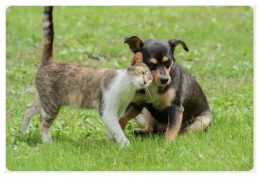

```python
image_path = "/content/drive/MyDrive/Colab Notebooks/homework_243/project on CLIP/dogcatimages/dogcat2.png"
image = Image.open(image_path).convert("RGB")

plt.imshow(image)
plt.axis("off")
plt.show()


# Text Prompts:
texts = [
    "a dog chasing a cat",
    "a cat chasing a dog",
    "a dog next to a cat",
    "a cat next to a dog",
    " a dog in the grass",
    "a cat in the grass",
    "a dog and a cat in the grass"
]
```

```python
prompts = [f"a photo of {text}" for text in texts]

for p in prompts:
    print(p)
```

```
a photo of a dog chasing a cat
a photo of a cat chasing a dog
a photo of a dog next to a cat
a photo of a cat next to a dog
a photo of  a dog in the grass
a photo of a cat in the grass
a photo of a dog and a cat in the grass
```

```python
inputs = processor(
    text=prompts,
    images=image,
    padding="max_length",
    return_tensors="pt"
).to(device)

with torch.no_grad():
    outputs = model(**inputs)

logits_per_image = outputs.logits_per_image
probs = torch.softmax(logits_per_image, dim=1)

pred_idx = probs.argmax(dim=1).item()

print("Predicted prompt:")
print(texts[pred_idx])

print("\nConfidence:")
print(probs[0, pred_idx].item())
```

```
Predicted prompt:
a dog and a cat in the grass

Confidence:
0.5611671805381775
```

```python
# full probabilities:
sorted_indices = torch.argsort(probs[0], descending=True)

print("SigLIP ranking:\n")

for idx in sorted_indices:
    print(f"{texts[idx]:35s}  {probs[0, idx].item():.4f}")
```

```
SigLIP ranking:

a dog and a cat in the grass         0.5612
a cat chasing a dog                  0.2208
a dog chasing a cat                  0.1797
a cat next to a dog                  0.0196
a dog next to a cat                  0.0177
 a dog in the grass                  0.0006
a cat in the grass                   0.0003
```

## Experiment 10: VQA using SigLIP:

### Multiple choice VQA using plain SigLIP:

SigLIP is an image-text matching model, similar to CLIP. It gives similarity scores between an image and text prompts. Hugging Face describes SigLIP as using separate image and text encoders to produce representations for both modalities, and the raw model is intended for tasks like zero-shot image classification and image-text retrieval.

We can use SigLIP for multiple-choice VQA by converting each possible answer into a full sentence.

```python
question = "What is happening in the image?"

answer_choices = [
    "a dog chasing a cat",
    "a cat chasing a dog",
    "a dog next to a cat",
    "a cat next to a dog",
    "a dog in the grass",
    "a cat in the grass",
    "a dog and a cat in the grass"
]

prompts = [f"Question: {question} Answer: {choice}." for choice in answer_choices]
```

```python
inputs = processor(
    text=prompts,
    images=image,
    padding="max_length",
    return_tensors="pt"
).to(device)

with torch.no_grad():
    outputs = model(**inputs)

logits = outputs.logits_per_image
probs = torch.softmax(logits, dim=1)

sorted_indices = torch.argsort(probs[0], descending=True)

print("SigLIP multiple-choice VQA ranking:\n")
for idx in sorted_indices:
    print(f"{answer_choices[idx]:35s}  {probs[0, idx].item():.4f}")

pred_idx = probs.argmax(dim=1).item()

print("\nQuestion:")
print(question)
print("\nPredicted answer:")
print(answer_choices[pred_idx])
```

```
SigLIP multiple-choice VQA ranking:

a dog and a cat in the grass         0.8666
a cat chasing a dog                  0.0508
a dog chasing a cat                  0.0390
a cat next to a dog                  0.0217
a dog next to a cat                  0.0192
a dog in the grass                   0.0018
a cat in the grass                   0.0007

Question:
What is happening in the image?

Predicted answer:
a dog and a cat in the grass
```

[PaliGemma 2: A Family of Versatile VLMs for Transfer](https://arxiv.org/abs/2412.03555)

Raw SigLIP is not a generative VQA model. It can be adapted to multiple-choice VQA by converting each candidate answer into a text prompt and selecting the answer with the highest image-text similarity. For open-ended VQA, a SigLIP-based vision-language model such as PaliGemma is more appropriate because it combines a SigLIP vision encoder with a Gemma language decoder and can generate natural-language answers.

PaliGemma is a vision-language model that combines a SigLIP vision encoder with a Gemma language decoder. The image is first divided into visual patches and encoded by SigLIP into a sequence of visual embeddings. These embeddings are passed through a projection layer so that they match the embedding space expected by the Gemma language model. The projected visual tokens are then combined with the text prompt tokens and given to the Gemma decoder, which generates the answer autoregressively. This makes PaliGemma different from CLIP or SigLIP: CLIP and SigLIP mainly compare image-text similarity, while PaliGemma can generate natural-language outputs for tasks such as image captioning and visual question answering.

**SigLIP is the visual understanding part; Gemma is the answer-generation part.**

```python
import torch
from PIL import Image
import matplotlib.pyplot as plt
from transformers import ViltProcessor, ViltForQuestionAnswering
```

```python
device = "cuda" if torch.cuda.is_available() else "cpu"

model_id = "dandelin/vilt-b32-finetuned-vqa"

processor = ViltProcessor.from_pretrained(model_id)
model = ViltForQuestionAnswering.from_pretrained(model_id).to(device)
model.eval()

print("Loaded:", model_id)
print("Device:", device)
```

[output not shown]

```
ViltForQuestionAnswering LOAD REPORT from: dandelin/vilt-b32-finetuned-vqa
Key                                          | Status     |  |
---------------------------------------------+------------+--+-
vilt.embeddings.text_embeddings.position_ids | UNEXPECTED |  |

Notes:
- UNEXPECTED	:can be ignored when loading from different task/architecture; not ok if you expect identical arch.
```

```
Loaded: dandelin/vilt-b32-finetuned-vqa
Device: cuda
```

```python
question = "What is happening in the image?"

encoding = processor(
    image,
    question,
    return_tensors="pt"
).to(device)

with torch.no_grad():
    outputs = model(**encoding)

logits = outputs.logits
pred_idx = logits.argmax(-1).item()

answer = model.config.id2label[pred_idx]

print("Question:", question)
print("Answer:", answer)
```

```
Question: What is happening in the image?
Answer: playing
```

```python
# Several questions:

questions = [
    "What animal is in the image?",
    "Is there a dog in the image?",
    "Is there a cat in the image?",
    "What is the dog doing?",
    "What is the cat doing?",
    "Are the dog and cat next to each other?",
    "What is happening in the image?"
]

for question in questions:
    encoding = processor(
        image,
        question,
        return_tensors="pt"
    ).to(device)

    with torch.no_grad():
        outputs = model(**encoding)

    logits = outputs.logits
    pred_idx = logits.argmax(-1).item()
    answer = model.config.id2label[pred_idx]

    print("Question:", question)
    print("Answer:", answer)
    print("-" * 50)
```

```
Question: What animal is in the image?
Answer: dog
--------------------------------------------------
Question: Is there a dog in the image?
Answer: yes
--------------------------------------------------
Question: Is there a cat in the image?
Answer: no
--------------------------------------------------
Question: What is the dog doing?
Answer: playing
--------------------------------------------------
Question: What is the cat doing?
Answer: walking
--------------------------------------------------
Question: Are the dog and cat next to each other?
Answer: yes
--------------------------------------------------
Question: What is happening in the image?
Answer: playing
--------------------------------------------------
```

```python
siglip_model_id = "google/siglip2-base-patch16-224"
# Alternative:
# siglip_model_id = "google/siglip-base-patch16-224"

siglip_processor = AutoProcessor.from_pretrained(siglip_model_id)
siglip_model = AutoModel.from_pretrained(siglip_model_id).to(device)
siglip_model.eval()

print("Loaded:", siglip_model_id)
```

```
Loaded: google/siglip2-base-patch16-224
```

```python
vilt_model_id = "dandelin/vilt-b32-finetuned-vqa"

vilt_processor = ViltProcessor.from_pretrained(vilt_model_id)
vilt_model = ViltForQuestionAnswering.from_pretrained(vilt_model_id).to(device)
vilt_model.eval()

print("Loaded:", vilt_model_id)
```

```
ViltForQuestionAnswering LOAD REPORT from: dandelin/vilt-b32-finetuned-vqa
Key                                          | Status     |  |
---------------------------------------------+------------+--+-
vilt.embeddings.text_embeddings.position_ids | UNEXPECTED |  |

Notes:
- UNEXPECTED	:can be ignored when loading from different task/architecture; not ok if you expect identical arch.
```

```
Loaded: dandelin/vilt-b32-finetuned-vqa
```

```python
def run_siglip_multiple_choice_vqa(image_path, question, answer_choices, model, processor, device):
    image = Image.open(image_path).convert("RGB")

    clean_choices = [a.strip() for a in answer_choices]

    prompts = [
        f"Question: {question} Answer: {answer}."
        for answer in clean_choices
    ]

    inputs = processor(
        text=prompts,
        images=image,
        padding="max_length",
        return_tensors="pt"
    ).to(device)

    with torch.no_grad():
        outputs = model(**inputs)

    logits = outputs.logits_per_image
    probs = torch.softmax(logits, dim=1)[0]

    results = pd.DataFrame({
        "answer_choice": clean_choices,
        "prompt_used": prompts,
        "probability": probs.detach().cpu().numpy()
    })

    results = results.sort_values("probability", ascending=False).reset_index(drop=True)

    print("Question:", question)
    print("Predicted answer:", results.loc[0, "answer_choice"])
    print("Confidence:", results.loc[0, "probability"])

    plt.figure(figsize=(10, 5))
    plt.bar(results["answer_choice"], results["probability"])
    plt.xticks(rotation=45, ha="right")
    plt.ylabel("Probability")
    plt.title("SigLIP Multiple-Choice VQA")
    plt.tight_layout()
    plt.show()

    display(results)

    return results
```

```
Question: What is happening in the image?
Predicted answer: a dog and a cat in the grass
Confidence: 0.5498651
```

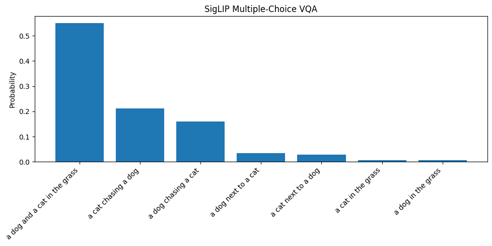

|  | answer_choice | prompt_used | probability |
| --- | --- | --- | --- |
| 0 | a dog and a cat in the grass | Question: What is happening in the image? Answ... | 0.549865 |
| 1 | a cat chasing a dog | Question: What is happening in the image? Answ... | 0.211914 |
| 2 | a dog chasing a cat | Question: What is happening in the image? Answ... | 0.160632 |
| 3 | a dog next to a cat | Question: What is happening in the image? Answ... | 0.035088 |
| 4 | a cat next to a dog | Question: What is happening in the image? Answ... | 0.029202 |
| 5 | a cat in the grass | Question: What is happening in the image? Answ... | 0.006662 |
| 6 | a dog in the grass | Question: What is happening in the image? Answ... | 0.006637 |

```python
question = "What is happening in the image?"

answer_choices = [
    "a dog chasing a cat",
    "a cat chasing a dog",
    "a dog next to a cat",
    "a cat next to a dog",
    "a dog in the grass",
    "a cat in the grass",
    "a dog and a cat in the grass"
]

vqa_siglip_results = run_siglip_multiple_choice_vqa(
    image_path=image_path,
    question=question,
    answer_choices=answer_choices,
    model=siglip_model,
    processor=siglip_processor,
    device=device
)
```

```python
def run_siglip_ranking(image_path, texts, model, processor, device, use_template=True):
    """
    Runs SigLIP/SigLIP 2 image-text ranking.

    image_path: path to image
    texts: list of candidate text prompts
    use_template: if True, converts each text to "a photo of ..."
    """

    image = Image.open(image_path).convert("RGB")

    clean_texts = [t.strip() for t in texts]

    if use_template:
        prompts = [f"a photo of {t}" for t in clean_texts]
    else:
        prompts = clean_texts

    inputs = processor(
        text=prompts,
        images=image,
        padding="max_length",
        return_tensors="pt"
    ).to(device)

    with torch.no_grad():
        outputs = model(**inputs)

    logits = outputs.logits_per_image
    probs = torch.softmax(logits, dim=1)[0]

    results = pd.DataFrame({
        "text": clean_texts,
        "prompt_used": prompts,
        "probability": probs.detach().cpu().numpy()
    })

    results = results.sort_values("probability", ascending=False).reset_index(drop=True)

    print("Predicted:", results.loc[0, "text"])
    print("Confidence:", results.loc[0, "probability"])

    plt.figure(figsize=(10, 5))
    plt.bar(results["text"], results["probability"])
    plt.xticks(rotation=45, ha="right")
    plt.ylabel("Probability")
    plt.title("SigLIP / SigLIP 2 Prompt Ranking")
    plt.tight_layout()
    plt.show()

    display(results)

    return results
```

```python
texts = [
    "a dog chasing a cat",
    "a cat chasing a dog",
    "a dog next to a cat",
    "a cat next to a dog",
    "a dog in the grass",
    "a cat in the grass"

]
```

```
Predicted: a cat chasing a dog
Confidence: 0.5105695
```

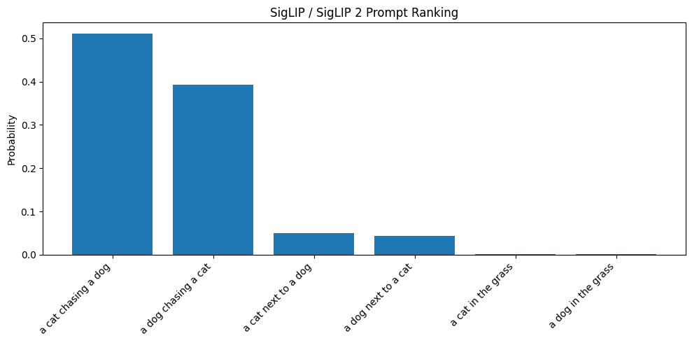

|  | text | prompt_used | probability |
| --- | --- | --- | --- |
| 0 | a cat chasing a dog | a photo of a cat chasing a dog | 0.510570 |
| 1 | a dog chasing a cat | a photo of a dog chasing a cat | 0.392895 |
| 2 | a cat next to a dog | a photo of a cat next to a dog | 0.049897 |
| 3 | a dog next to a cat | a photo of a dog next to a cat | 0.043700 |
| 4 | a cat in the grass | a photo of a cat in the grass | 0.001624 |
| 5 | a dog in the grass | a photo of a dog in the grass | 0.001315 |

```python
siglip_results = run_siglip_ranking(
    image_path=image_path,
    texts=texts,
    model=siglip_model,
    processor=siglip_processor,
    device=device,
    use_template=True
)
```

#### Counting with SigLIP

```
Predicted: one dog
Confidence: 0.5036906
```

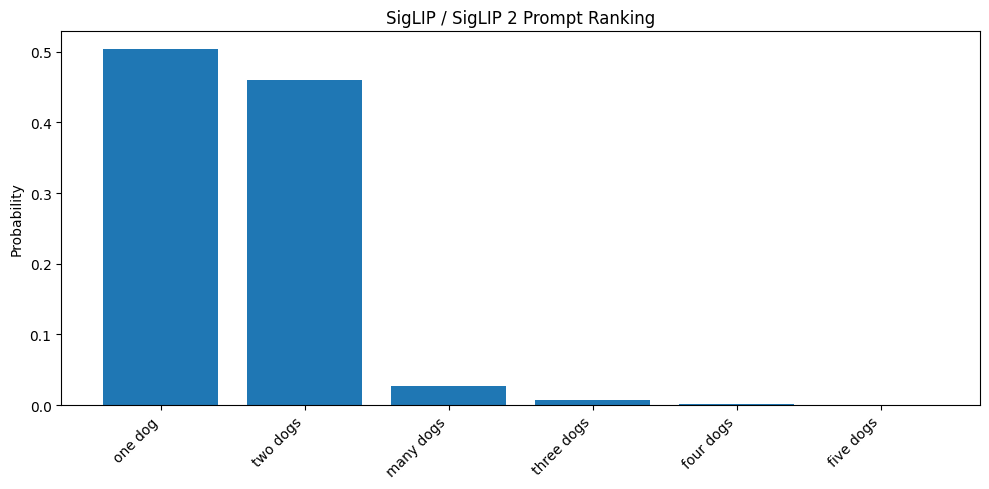

|  | text | prompt_used | probability |
| --- | --- | --- | --- |
| 0 | one dog | a photo of one dog | 0.503691 |
| 1 | two dogs | a photo of two dogs | 0.460040 |
| 2 | many dogs | a photo of many dogs | 0.027208 |
| 3 | three dogs | a photo of three dogs | 0.006637 |
| 4 | four dogs | a photo of four dogs | 0.001755 |
| 5 | five dogs | a photo of five dogs | 0.000669 |

```python
# counting with SigLIP:

counting_texts = [
    "one dog",
    "two dogs",
    "three dogs",
    "four dogs",
    "five dogs",
    "many dogs"
]

counting_results = run_siglip_ranking(
    image_path=image_path,
    texts=counting_texts,
    model=siglip_model,
    processor=siglip_processor,
    device=device,
    use_template=True
)
```

```
Question: How many dogs are in the image?
Predicted answer: two dogs
Confidence: 0.3967182
```

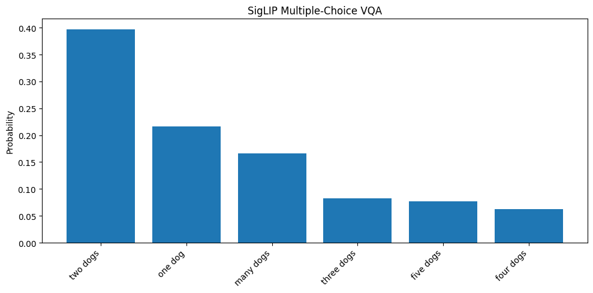

|  | answer_choice | prompt_used | probability |
| --- | --- | --- | --- |
| 0 | two dogs | Question: How many dogs are in the image? Answ... | 0.396718 |
| 1 | one dog | Question: How many dogs are in the image? Answ... | 0.216068 |
| 2 | many dogs | Question: How many dogs are in the image? Answ... | 0.166168 |
| 3 | three dogs | Question: How many dogs are in the image? Answ... | 0.082199 |
| 4 | five dogs | Question: How many dogs are in the image? Answ... | 0.076541 |
| 5 | four dogs | Question: How many dogs are in the image? Answ... | 0.062306 |

```python
counting_question = "How many dogs are in the image?"

counting_choices = [
    "one dog",
    "two dogs",
    "three dogs",
    "four dogs",
    "five dogs",
    "many dogs"
]

counting_vqa_results = run_siglip_multiple_choice_vqa(
    image_path=image_path,
    question=counting_question,
    answer_choices=counting_choices,
    model=siglip_model,
    processor=siglip_processor,
    device=device
)
```

```python
def ask_vilt(image_path, question, model, processor, device):
    image = Image.open(image_path).convert("RGB")

    encoding = processor(
        image,
        question,
        return_tensors="pt"
    ).to(device)

    with torch.no_grad():
        outputs = model(**encoding)

    logits = outputs.logits
    probs = torch.softmax(logits, dim=-1)

    pred_idx = logits.argmax(-1).item()
    answer = model.config.id2label[pred_idx]
    confidence = probs[0, pred_idx].item()

    return answer, confidence
```

```python
count_questions = [
    "How many dogs are in the image?",
    "How many cats are in the image?",
    "How many animals are in the image?"
]

count_vilt_answers = []

for q in count_questions:
    answer, confidence = ask_vilt(
        image_path=image_path,
        question=q,
        model=vilt_model,
        processor=vilt_processor,
        device=device
    )

    count_vilt_answers.append({
        "question": q,
        "answer": answer,
        "confidence": confidence
    })

count_vilt_df = pd.DataFrame(count_vilt_answers)
display(count_vilt_df)
```

|  | question | answer | confidence |
| --- | --- | --- | --- |
| 0 | How many dogs are in the image? | 2 | 0.746856 |
| 1 | How many cats are in the image? | 0 | 0.989216 |
| 2 | How many animals are in the image? | 2 | 0.998796 |

## Experiment 12: Experiment on the MNIST

```python
import torchvision.transforms as transforms
from torchvision.datasets import MNIST


mnist_transform = transforms.Compose([
    transforms.Resize((224, 224)),
    transforms.Grayscale(num_output_channels=3),
    transforms.ToTensor()
])

mnist_dataset = MNIST(
    root="/content/data",
    train=False,
    download=True,
    transform=None
)
```

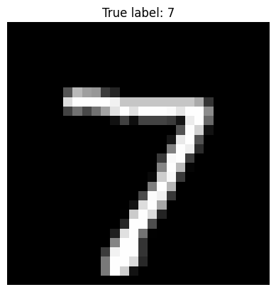

```python
idx = 0

mnist_image, true_label = mnist_dataset[idx]

plt.imshow(mnist_image, cmap="gray")
plt.axis("off")
plt.title(f"True label: {true_label}")
plt.show()

mnist_image_rgb = mnist_image.convert("RGB").resize((224, 224))
```

```python
mnist_texts = [
    "a handwritten digit zero",
    "a handwritten digit one",
    "a handwritten digit two",
    "a handwritten digit three",
    "a handwritten digit four",
    "a handwritten digit five",
    "a handwritten digit six",
    "a handwritten digit seven",
    "a handwritten digit eight",
    "a handwritten digit nine"
]
```

```python
def run_siglip_ranking_pil(image, texts, model, processor, device, use_template=False):
    clean_texts = [t.strip() for t in texts]

    if use_template:
        prompts = [f"a photo of {t}" for t in clean_texts]
    else:
        prompts = clean_texts

    inputs = processor(
        text=prompts,
        images=image,
        padding="max_length",
        return_tensors="pt"
    ).to(device)

    with torch.no_grad():
        outputs = model(**inputs)

    logits = outputs.logits_per_image
    probs = torch.softmax(logits, dim=1)[0]

    results = pd.DataFrame({
        "text": clean_texts,
        "probability": probs.detach().cpu().numpy()
    })

    results = results.sort_values("probability", ascending=False).reset_index(drop=True)

    print("Predicted:", results.loc[0, "text"])
    print("True label:", true_label)

    plt.figure(figsize=(10, 5))
    plt.bar(results["text"], results["probability"])
    plt.xticks(rotation=45, ha="right")
    plt.ylabel("Probability")
    plt.title("SigLIP Zero-Shot on MNIST")
    plt.tight_layout()
    plt.show()

    display(results)

    return results
```

```
Predicted: a handwritten digit seven
True label: 7
```

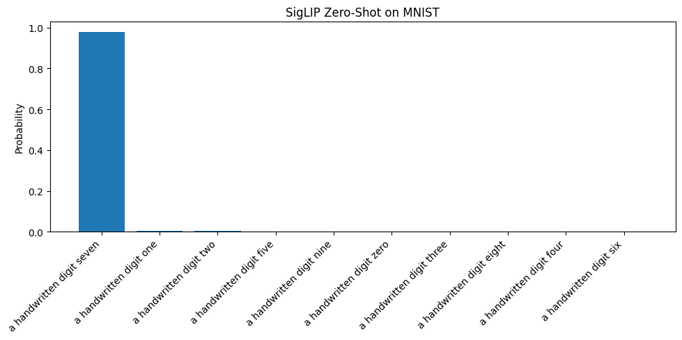

|  | text | probability |
| --- | --- | --- |
| 0 | a handwritten digit seven | 0.978903 |
| 1 | a handwritten digit one | 0.004388 |
| 2 | a handwritten digit two | 0.003961 |
| 3 | a handwritten digit five | 0.002614 |
| 4 | a handwritten digit nine | 0.002527 |
| 5 | a handwritten digit zero | 0.002475 |
| 6 | a handwritten digit three | 0.002092 |
| 7 | a handwritten digit eight | 0.001306 |
| 8 | a handwritten digit four | 0.001025 |
| 9 | a handwritten digit six | 0.000711 |

```python
mnist_result = run_siglip_ranking_pil(
    image=mnist_image_rgb,
    texts=mnist_texts,
    model=siglip_model,
    processor=siglip_processor,
    device=device,
    use_template=False
)
```

```python
digit_words = [
    "zero", "one", "two", "three", "four",
    "five", "six", "seven", "eight", "nine"
]

mnist_texts = [
    f"a handwritten digit {word}"
    for word in digit_words
]

def predict_mnist_siglip(image, texts, model, processor, device):
    image_rgb = image.convert("RGB").resize((224, 224))

    inputs = processor(
        text=texts,
        images=image_rgb,
        padding="max_length",
        return_tensors="pt"
    ).to(device)

    with torch.no_grad():
        outputs = model(**inputs)

    probs = torch.softmax(outputs.logits_per_image, dim=1)[0]
    pred_idx = probs.argmax().item()

    return pred_idx, probs[pred_idx].item()
```

```python
num_samples = 1000

records = []

for i in range(num_samples):
    image, true_label = mnist_dataset[i]

    pred_label, confidence = predict_mnist_siglip(
        image=image,
        texts=mnist_texts,
        model=siglip_model,
        processor=siglip_processor,
        device=device
    )

    records.append({
        "index": i,
        "true_label": true_label,
        "pred_label": pred_label,
        "correct": int(true_label == pred_label),
        "confidence": confidence
    })

mnist_eval_df = pd.DataFrame(records)

accuracy = mnist_eval_df["correct"].mean()

print(f"MNIST zero-shot SigLIP accuracy on {num_samples} samples: {accuracy:.4f}")

display(mnist_eval_df.head(20))
```

```
MNIST zero-shot SigLIP accuracy on 1000 samples: 0.7860
```

|  | index | true_label | pred_label | correct | confidence |
| --- | --- | --- | --- | --- | --- |
| 0 | 0 | 7 | 7 | 1 | 0.978903 |
| 1 | 1 | 2 | 2 | 1 | 0.954687 |
| 2 | 2 | 1 | 1 | 1 | 0.422162 |
| 3 | 3 | 0 | 0 | 1 | 0.545407 |
| 4 | 4 | 4 | 4 | 1 | 0.962021 |
| 5 | 5 | 1 | 1 | 1 | 0.368136 |
| 6 | 6 | 4 | 4 | 1 | 0.439969 |
| 7 | 7 | 9 | 1 | 0 | 0.149480 |
| 8 | 8 | 5 | 2 | 0 | 0.163896 |
| 9 | 9 | 9 | 7 | 0 | 0.540229 |
| 10 | 10 | 0 | 0 | 1 | 0.520161 |
| 11 | 11 | 6 | 6 | 1 | 0.324550 |
| 12 | 12 | 9 | 9 | 1 | 0.579795 |
| 13 | 13 | 0 | 0 | 1 | 0.839516 |
| 14 | 14 | 1 | 1 | 1 | 0.480698 |
| 15 | 15 | 5 | 5 | 1 | 0.873218 |
| 16 | 16 | 9 | 9 | 1 | 0.770323 |
| 17 | 17 | 7 | 7 | 1 | 0.841384 |
| 18 | 18 | 3 | 8 | 0 | 0.265143 |
| 19 | 19 | 4 | 4 | 1 | 0.980159 |

```python
num_samples = 1000

records = []

for i in range(num_samples):
    image, true_label = mnist_dataset[i]

    pred_label, confidence = predict_mnist_siglip(
        image=image,
        texts=mnist_texts,
        model=siglip_model,
        processor=siglip_processor,
        device=device
    )

    records.append({
        "index": i,
        "true_label": true_label,
        "pred_label": pred_label,
        "correct": int(true_label == pred_label),
        "confidence": confidence
    })

mnist_eval_df = pd.DataFrame(records)

accuracy = mnist_eval_df["correct"].mean()

print(f"MNIST zero-shot SigLIP accuracy on {num_samples} samples: {accuracy:.4f}")

display(mnist_eval_df.head(20))
```

```
MNIST zero-shot SigLIP accuracy on 1000 samples: 0.7860
```

|  | index | true_label | pred_label | correct | confidence |
| --- | --- | --- | --- | --- | --- |
| 0 | 0 | 7 | 7 | 1 | 0.978903 |
| 1 | 1 | 2 | 2 | 1 | 0.954687 |
| 2 | 2 | 1 | 1 | 1 | 0.422162 |
| 3 | 3 | 0 | 0 | 1 | 0.545407 |
| 4 | 4 | 4 | 4 | 1 | 0.962021 |
| 5 | 5 | 1 | 1 | 1 | 0.368136 |
| 6 | 6 | 4 | 4 | 1 | 0.439969 |
| 7 | 7 | 9 | 1 | 0 | 0.149480 |
| 8 | 8 | 5 | 2 | 0 | 0.163896 |
| 9 | 9 | 9 | 7 | 0 | 0.540229 |
| 10 | 10 | 0 | 0 | 1 | 0.520161 |
| 11 | 11 | 6 | 6 | 1 | 0.324550 |
| 12 | 12 | 9 | 9 | 1 | 0.579795 |
| 13 | 13 | 0 | 0 | 1 | 0.839516 |
| 14 | 14 | 1 | 1 | 1 | 0.480698 |
| 15 | 15 | 5 | 5 | 1 | 0.873218 |
| 16 | 16 | 9 | 9 | 1 | 0.770323 |
| 17 | 17 | 7 | 7 | 1 | 0.841384 |
| 18 | 18 | 3 | 8 | 0 | 0.265143 |
| 19 | 19 | 4 | 4 | 1 | 0.980159 |

```python
num_samples = 1000

records = []

for i in range(num_samples):
    image, true_label = mnist_dataset[i]

    pred_label, confidence = predict_mnist_siglip(
        image=image,
        texts=mnist_texts,
        model=siglip_model,
        processor=siglip_processor,
        device=device
    )

    records.append({
        "index": i,
        "true_label": true_label,
        "pred_label": pred_label,
        "correct": int(true_label == pred_label),
        "confidence": confidence
    })

mnist_eval_df = pd.DataFrame(records)

accuracy = mnist_eval_df["correct"].mean()

print(f"MNIST zero-shot SigLIP accuracy on {num_samples} samples: {accuracy:.4f}")

display(mnist_eval_df.head(20))
```

```
MNIST zero-shot SigLIP accuracy on 1000 samples: 0.7860
```

|  | index | true_label | pred_label | correct | confidence |
| --- | --- | --- | --- | --- | --- |
| 0 | 0 | 7 | 7 | 1 | 0.978903 |
| 1 | 1 | 2 | 2 | 1 | 0.954687 |
| 2 | 2 | 1 | 1 | 1 | 0.422162 |
| 3 | 3 | 0 | 0 | 1 | 0.545407 |
| 4 | 4 | 4 | 4 | 1 | 0.962021 |
| 5 | 5 | 1 | 1 | 1 | 0.368136 |
| 6 | 6 | 4 | 4 | 1 | 0.439969 |
| 7 | 7 | 9 | 1 | 0 | 0.149480 |
| 8 | 8 | 5 | 2 | 0 | 0.163896 |
| 9 | 9 | 9 | 7 | 0 | 0.540229 |
| 10 | 10 | 0 | 0 | 1 | 0.520161 |
| 11 | 11 | 6 | 6 | 1 | 0.324550 |
| 12 | 12 | 9 | 9 | 1 | 0.579795 |
| 13 | 13 | 0 | 0 | 1 | 0.839516 |
| 14 | 14 | 1 | 1 | 1 | 0.480698 |
| 15 | 15 | 5 | 5 | 1 | 0.873218 |
| 16 | 16 | 9 | 9 | 1 | 0.770323 |
| 17 | 17 | 7 | 7 | 1 | 0.841384 |
| 18 | 18 | 3 | 8 | 0 | 0.265143 |
| 19 | 19 | 4 | 4 | 1 | 0.980159 |

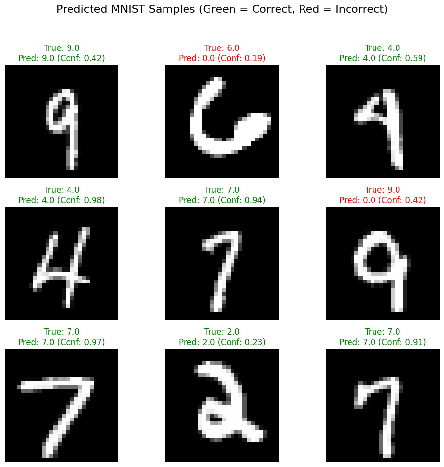

```python
import matplotlib.pyplot as plt

# Select a few random samples from the evaluation DataFrame
samples_to_plot = mnist_eval_df.sample(n=9, random_state=42)

plt.figure(figsize=(10, 10))

for i, (idx, row) in enumerate(samples_to_plot.iterrows()):
    image_index = int(row['index']) # Cast to int
    true_label = row['true_label']
    pred_label = row['pred_label']
    confidence = row['confidence']
    is_correct = row['correct']

    # Get the actual image from the MNIST dataset
    image, _ = mnist_dataset[image_index]

    plt.subplot(3, 3, i + 1)
    plt.imshow(image, cmap='gray')
    plt.axis('off')

    color = 'green' if is_correct else 'red'
    plt.title(f"True: {true_label}\nPred: {pred_label} (Conf: {confidence:.2f})", color=color)

plt.suptitle("Predicted MNIST Samples (Green = Correct, Red = Incorrect)", fontsize=16)
plt.tight_layout(rect=[0, 0.03, 1, 0.95]) # Adjust layout to prevent title overlap
plt.show()
```

```python
print("Running MNIST zero-shot classification with CLIP model...")

import torch
from transformers import CLIPProcessor, CLIPModel

# Load CLIP model and processor specifically for this task to avoid conflicts
clip_model_id = "openai/clip-vit-base-patch32"
clip_model = CLIPModel.from_pretrained(clip_model_id).to(device)
clip_processor = CLIPProcessor.from_pretrained(clip_model_id)

def predict_mnist_clip(image, texts, model, processor, device):
    image_rgb = image.convert("RGB").resize((224, 224))

    inputs = processor(
        text=texts,
        images=image_rgb,
        padding="max_length",
        return_tensors="pt"
    ).to(device)

    with torch.no_grad():
        outputs = model(**inputs)

    probs = outputs.logits_per_image.softmax(dim=1)[0]
    pred_idx = probs.argmax().item()

    return pred_idx, probs[pred_idx].item()


records_clip = []
num_samples = 1000
# `mnist_dataset` and `mnist_texts` are already defined from previous cells
for i in tqdm(range(num_samples), desc="CLIP MNIST Eval"):
    image, true_label = mnist_dataset[i]

    pred_label, confidence = predict_mnist_clip(
        image=image,
        texts=mnist_texts,
        model=clip_model, # Use the dedicated CLIP model
        processor=clip_processor, # Use the dedicated CLIP processor
        device=device
    )

    records_clip.append({
        "index": i,
        "true_label": true_label,
        "pred_label": pred_label,
        "correct": int(true_label == pred_label),
        "confidence": confidence
    })

mnist_eval_df_clip = pd.DataFrame(records_clip)

accuracy_clip = mnist_eval_df_clip["correct"].mean()

print(f"\nMNIST zero-shot CLIP accuracy on {len(mnist_dataset)} samples: {accuracy_clip:.4f}")

display(mnist_eval_df_clip.head(20))

# Also update the prompt_df with CLIP's performance for comparison
prompt_df = pd.concat([
    prompt_df,
    pd.DataFrame([{"Prompt Style": "CLIP zero-shot MNIST", "Accuracy": accuracy_clip}])
], ignore_index=True)

print("\nUpdated prompt comparison:")
display(prompt_df)
```

```
Running MNIST zero-shot classification with CLIP model...
```

[output not shown]

[output not shown]

|  | index | true_label | pred_label | correct | confidence |
| --- | --- | --- | --- | --- | --- |
| 0 | 0 | 7 | 2 | 0 | 0.318350 |
| 1 | 1 | 2 | 2 | 1 | 0.261386 |
| 2 | 2 | 1 | 2 | 0 | 0.157818 |
| 3 | 3 | 0 | 0 | 1 | 0.153450 |
| 4 | 4 | 4 | 3 | 0 | 0.145998 |
| 5 | 5 | 1 | 2 | 0 | 0.163126 |
| 6 | 6 | 4 | 2 | 0 | 0.167360 |
| 7 | 7 | 9 | 8 | 0 | 0.158489 |
| 8 | 8 | 5 | 0 | 0 | 0.149622 |
| 9 | 9 | 9 | 2 | 0 | 0.206954 |
| 10 | 10 | 0 | 0 | 1 | 0.181330 |
| 11 | 11 | 6 | 2 | 0 | 0.148605 |
| 12 | 12 | 9 | 2 | 0 | 0.134779 |
| 13 | 13 | 0 | 0 | 1 | 0.225531 |
| 14 | 14 | 1 | 2 | 0 | 0.173748 |
| 15 | 15 | 5 | 6 | 0 | 0.201031 |
| 16 | 16 | 9 | 2 | 0 | 0.143922 |
| 17 | 17 | 7 | 2 | 0 | 0.272449 |
| 18 | 18 | 3 | 2 | 0 | 0.149082 |
| 19 | 19 | 4 | 3 | 0 | 0.186083 |

```
Updated prompt comparison:
```

|  | Prompt Style | Accuracy |
| --- | --- | --- |
| 0 | handwritten digit | 0.2270 |
| 1 | number only | 0.3068 |
| 2 | image of digit | 0.2814 |
| 3 | mnist style | 0.1393 |
| 4 | CLIP zero-shot MNIST | 0.2530 |

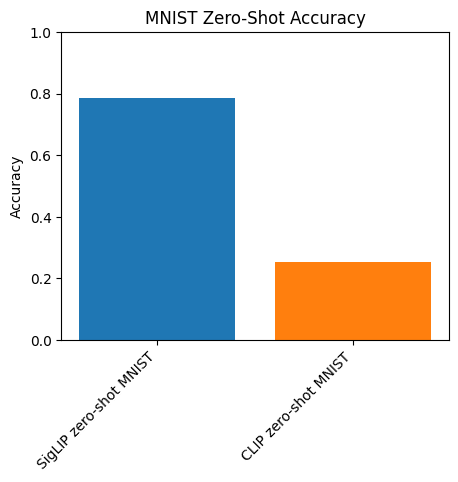

```python
plt.figure(figsize=(5, 4))
plt.bar(["SigLIP zero-shot MNIST"], [accuracy])
plt.bar(["CLIP zero-shot MNIST"], [accuracy_clip])
plt.xticks(rotation=45, ha="right")
plt.ylim(0, 1)
plt.ylabel("Accuracy")
plt.title("MNIST Zero-Shot Accuracy")
plt.show()
```